# Optimal Treatment Analysis

## Outcome Variable

**Outcome Variable:** haz

## Predictor Variables

**Intervention Variable:** parity

**Adjustment Set:**

- arm
- W_mage
- meducyrs
- feducyrs
- hhwealth_quart
- W_mhtcm
- W_mwtkg
- W_mbmi
- vagbrth
- W_nrooms
- impsan
- delta_W_mage
- delta_meducyrs
- delta_feducyrs
- delta_hhwealth_quart
- delta_W_mhtcm
- delta_W_mwtkg
- delta_W_mbmi
- delta_vagbrth
- delta_W_nrooms
- delta_impsan

## Stratifying Variables

The analysis was stratified on these variable(s):

- agecat
- studyid
- country

## Data Summary

| agecat | studyid | country | parity | n_cell | n |
| --- | --- | --- | --- | --- | --- |
| Birth | COHORTS | GUATEMALA | 1 | 112 | 852 |
| Birth | COHORTS | GUATEMALA | 2 | 137 | 852 |
| Birth | COHORTS | GUATEMALA | 3+ | 603 | 852 |
| Birth | COHORTS | INDIA | 1 | 696 | 4122 |
| Birth | COHORTS | INDIA | 2 | 1037 | 4122 |
| Birth | COHORTS | INDIA | 3+ | 2389 | 4122 |
| Birth | COHORTS | PHILIPPINES | 1 | 675 | 3050 |
| Birth | COHORTS | PHILIPPINES | 2 | 687 | 3050 |
| Birth | COHORTS | PHILIPPINES | 3+ | 1688 | 3050 |
| Birth | GMS-Nepal | NEPAL | 1 | 211 | 696 |
| Birth | GMS-Nepal | NEPAL | 2 | 180 | 696 |
| Birth | GMS-Nepal | NEPAL | 3+ | 305 | 696 |
| Birth | JiVitA-3 | BANGLADESH | 1 | 7456 | 22455 |
| Birth | JiVitA-3 | BANGLADESH | 2 | 7615 | 22455 |
| Birth | JiVitA-3 | BANGLADESH | 3+ | 7384 | 22455 |
| Birth | Keneba | GAMBIA | 1 | 156 | 1407 |
| Birth | Keneba | GAMBIA | 2 | 146 | 1407 |
| Birth | Keneba | GAMBIA | 3+ | 1105 | 1407 |
| Birth | PROVIDE | BANGLADESH | 1 | 206 | 539 |
| Birth | PROVIDE | BANGLADESH | 2 | 183 | 539 |
| Birth | PROVIDE | BANGLADESH | 3+ | 150 | 539 |
| Birth | SAS-CompFeed | INDIA | 1 | 361 | 1252 |
| Birth | SAS-CompFeed | INDIA | 2 | 289 | 1252 |
| Birth | SAS-CompFeed | INDIA | 3+ | 602 | 1252 |
| Birth | ZVITAMBO | ZIMBABWE | 1 | 5989 | 13874 |
| Birth | ZVITAMBO | ZIMBABWE | 2 | 4144 | 13874 |
| Birth | ZVITAMBO | ZIMBABWE | 3+ | 3741 | 13874 |
| 6 months | COHORTS | GUATEMALA | 1 | 132 | 961 |
| 6 months | COHORTS | GUATEMALA | 2 | 139 | 961 |
| 6 months | COHORTS | GUATEMALA | 3+ | 690 | 961 |

[output cut: 57 more lines]

The following strata were considered:

- agecat: 24 months, studyid: COHORTS, country: GUATEMALA
- agecat: 24 months, studyid: COHORTS, country: INDIA
- agecat: 24 months, studyid: COHORTS, country: PHILIPPINES
- agecat: 24 months, studyid: GMS-Nepal, country: NEPAL
- agecat: 24 months, studyid: JiVitA-3, country: BANGLADESH
- agecat: 24 months, studyid: Keneba, country: GAMBIA
- agecat: 24 months, studyid: PROVIDE, country: BANGLADESH
- agecat: 24 months, studyid: TanzaniaChild2, country: TANZANIA, UNITED REPUBLIC OF
- agecat: 24 months, studyid: ZVITAMBO, country: ZIMBABWE
- agecat: 6 months, studyid: COHORTS, country: GUATEMALA
- agecat: 6 months, studyid: COHORTS, country: INDIA
- agecat: 6 months, studyid: COHORTS, country: PHILIPPINES
- agecat: 6 months, studyid: GMS-Nepal, country: NEPAL
- agecat: 6 months, studyid: JiVitA-3, country: BANGLADESH
- agecat: 6 months, studyid: Keneba, country: GAMBIA
- agecat: 6 months, studyid: PROVIDE, country: BANGLADESH
- agecat: 6 months, studyid: SAS-CompFeed, country: INDIA
- agecat: 6 months, studyid: SAS-FoodSuppl, country: INDIA
- agecat: 6 months, studyid: TanzaniaChild2, country: TANZANIA, UNITED REPUBLIC OF
- agecat: 6 months, studyid: ZVITAMBO, country: ZIMBABWE
- agecat: Birth, studyid: COHORTS, country: GUATEMALA
- agecat: Birth, studyid: COHORTS, country: INDIA
- agecat: Birth, studyid: COHORTS, country: PHILIPPINES
- agecat: Birth, studyid: GMS-Nepal, country: NEPAL
- agecat: Birth, studyid: JiVitA-3, country: BANGLADESH
- agecat: Birth, studyid: Keneba, country: GAMBIA
- agecat: Birth, studyid: PROVIDE, country: BANGLADESH
- agecat: Birth, studyid: SAS-CompFeed, country: INDIA
- agecat: Birth, studyid: ZVITAMBO, country: ZIMBABWE

### Dropped Strata

Some strata were dropped due to rare outcomes:

- agecat: 24 months, studyid: TanzaniaChild2, country: TANZANIA, UNITED REPUBLIC OF

## Methods Detail

We’re interested in the causal parameters $E[Y_a]$ for all values of $a \in \mathcal{A}$. These parameters represent the mean outcome if, possibly contrary to fact, we intervened to set all units to have $A=a$. Under the randomization and positivity assumptions, these are identified by the statistical parameters $\psi_a=E_W[E_{Y|A,W}(Y|A=a,W)]$. In addition, we’re interested in the mean of $Y$, $E[Y]$ under no intervention (the observed mean). We will estimate these parameters by using SuperLearner to fit the relevant likelihood factors – $E_{Y|A,W}(Y|A=a,W)$ and $p(A=a|W)$, and then updating our likelihood fit using a joint TMLE.

For unadjusted analyses ($W=\{\}$), initial likelihoods were estimated using Lrnr_glm to estimate the simple $E(Y|A)$ and Lrnr_mean to estimate $p(A)$. For adjusted analyses, a small library containing Lrnr_glmnet, Lrnr_xgboost, and Lrnr_mean was used.

Having estimated these parameters, we will then use the delta method to estimate relative risks and attributable risks relative to a prespecified baseline level of $A$.

# Results Detail

## Results Plots

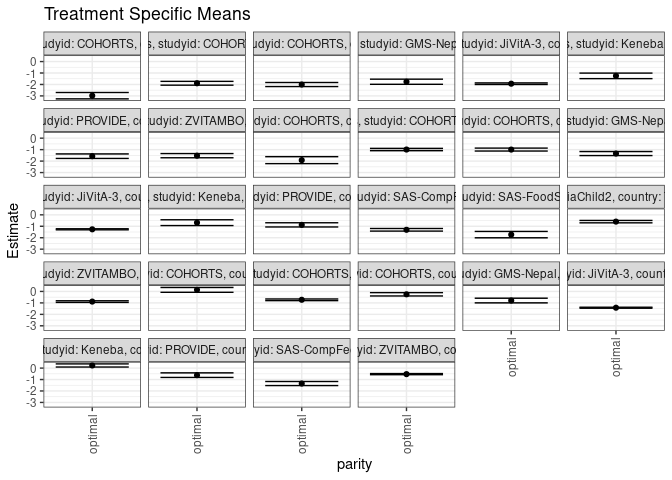

## Results Table

### Parameter: TSM

| agecat | studyid | country | intervention_level | baseline_level | estimate | ci_lower | ci_upper |
| --- | --- | --- | --- | --- | --- | --- | --- |
| Birth | COHORTS | GUATEMALA | optimal | observed | 0.1367849 | -0.0739481 | 0.3475178 |
| Birth | COHORTS | INDIA | optimal | observed | -0.7278774 | -0.7994345 | -0.6563202 |
| Birth | COHORTS | PHILIPPINES | optimal | observed | -0.2497066 | -0.3955639 | -0.1038493 |
| Birth | GMS-Nepal | NEPAL | optimal | observed | -0.7930346 | -0.9961904 | -0.5898788 |
| Birth | JiVitA-3 | BANGLADESH | optimal | observed | -1.4201488 | -1.4632821 | -1.3770155 |
| Birth | Keneba | GAMBIA | optimal | observed | 0.2273705 | 0.0901644 | 0.3645765 |
| Birth | PROVIDE | BANGLADESH | optimal | observed | -0.6180335 | -0.8184340 | -0.4176330 |
| Birth | SAS-CompFeed | INDIA | optimal | observed | -1.3496781 | -1.5269550 | -1.1724011 |
| Birth | ZVITAMBO | ZIMBABWE | optimal | observed | -0.5289005 | -0.5793654 | -0.4784357 |
| 6 months | COHORTS | GUATEMALA | optimal | observed | -1.9182614 | -2.2224598 | -1.6140631 |
| 6 months | COHORTS | INDIA | optimal | observed | -0.9911681 | -1.0893906 | -0.8929456 |
| 6 months | COHORTS | PHILIPPINES | optimal | observed | -0.9953028 | -1.1229735 | -0.8676320 |
| 6 months | GMS-Nepal | NEPAL | optimal | observed | -1.3420642 | -1.5180237 | -1.1661047 |
| 6 months | JiVitA-3 | BANGLADESH | optimal | observed | -1.2660161 | -1.3113021 | -1.2207300 |
| 6 months | Keneba | GAMBIA | optimal | observed | -0.6853006 | -0.9371548 | -0.4334463 |
| 6 months | PROVIDE | BANGLADESH | optimal | observed | -0.8780642 | -1.0607525 | -0.6953759 |
| 6 months | SAS-CompFeed | INDIA | optimal | observed | -1.3077672 | -1.4208862 | -1.1946482 |
| 6 months | SAS-FoodSuppl | INDIA | optimal | observed | -1.7291517 | -2.0069779 | -1.4513256 |
| 6 months | TanzaniaChild2 | TANZANIA, UNITED REPUBLIC OF | optimal | observed | -0.5940852 | -0.6982967 | -0.4898738 |
| 6 months | ZVITAMBO | ZIMBABWE | optimal | observed | -0.8846475 | -0.9564264 | -0.8128685 |
| 24 months | COHORTS | GUATEMALA | optimal | observed | -2.9792040 | -3.2575761 | -2.7008318 |
| 24 months | COHORTS | INDIA | optimal | observed | -1.8953959 | -2.0619865 | -1.7288053 |
| 24 months | COHORTS | PHILIPPINES | optimal | observed | -2.0057863 | -2.1834064 | -1.8281663 |
| 24 months | GMS-Nepal | NEPAL | optimal | observed | -1.7636655 | -1.9874935 | -1.5398375 |
| 24 months | JiVitA-3 | BANGLADESH | optimal | observed | -1.9343046 | -2.0011649 | -1.8674442 |
| 24 months | Keneba | GAMBIA | optimal | observed | -1.2499025 | -1.4899870 | -1.0098180 |
| 24 months | PROVIDE | BANGLADESH | optimal | observed | -1.5716158 | -1.7678222 | -1.3754094 |
| 24 months | ZVITAMBO | ZIMBABWE | optimal | observed | -1.5267338 | -1.7088538 | -1.3446139 |

### Parameter: E(Y)

| agecat | studyid | country | intervention_level | baseline_level | estimate | ci_lower | ci_upper |
| --- | --- | --- | --- | --- | --- | --- | --- |
| Birth | COHORTS | GUATEMALA | observed | observed | 0.1297300 | 0.0458017 | 0.2136584 |
| Birth | COHORTS | INDIA | observed | observed | -0.6773241 | -0.7124609 | -0.6421873 |
| Birth | COHORTS | PHILIPPINES | observed | observed | -0.2490492 | -0.2880580 | -0.2100404 |
| Birth | GMS-Nepal | NEPAL | observed | observed | -1.0851580 | -1.1651811 | -1.0051350 |
| Birth | JiVitA-3 | BANGLADESH | observed | observed | -1.5894148 | -1.6086362 | -1.5701935 |
| Birth | Keneba | GAMBIA | observed | observed | 0.0483298 | -0.0182746 | 0.1149342 |
| Birth | PROVIDE | BANGLADESH | observed | observed | -0.8851020 | -0.9601332 | -0.8100709 |
| Birth | SAS-CompFeed | INDIA | observed | observed | -1.4314217 | -1.5099245 | -1.3529189 |
| Birth | ZVITAMBO | ZIMBABWE | observed | observed | -0.5003222 | -0.5208673 | -0.4797770 |
| 6 months | COHORTS | GUATEMALA | observed | observed | -1.8157336 | -1.8837688 | -1.7476985 |
| 6 months | COHORTS | INDIA | observed | observed | -1.0455022 | -1.0805318 | -1.0104727 |
| 6 months | COHORTS | PHILIPPINES | observed | observed | -1.1405724 | -1.1824954 | -1.0986493 |
| 6 months | GMS-Nepal | NEPAL | observed | observed | -1.3508392 | -1.4290633 | -1.2726152 |
| 6 months | JiVitA-3 | BANGLADESH | observed | observed | -1.3130932 | -1.3362359 | -1.2899505 |
| 6 months | Keneba | GAMBIA | observed | observed | -0.9239386 | -0.9768148 | -0.8710623 |
| 6 months | PROVIDE | BANGLADESH | observed | observed | -1.0916915 | -1.1661176 | -1.0172654 |
| 6 months | SAS-CompFeed | INDIA | observed | observed | -1.4018563 | -1.4810585 | -1.3226541 |
| 6 months | SAS-FoodSuppl | INDIA | observed | observed | -1.8986842 | -2.0118892 | -1.7854792 |
| 6 months | TanzaniaChild2 | TANZANIA, UNITED REPUBLIC OF | observed | observed | -0.5432778 | -0.5926218 | -0.4939338 |
| 6 months | ZVITAMBO | ZIMBABWE | observed | observed | -0.8679886 | -0.8935535 | -0.8424236 |
| 24 months | COHORTS | GUATEMALA | observed | observed | -2.9905921 | -3.0548289 | -2.9263553 |
| 24 months | COHORTS | INDIA | observed | observed | -2.2397574 | -2.2808841 | -2.1986307 |
| 24 months | COHORTS | PHILIPPINES | observed | observed | -2.4141145 | -2.4590818 | -2.3691473 |
| 24 months | GMS-Nepal | NEPAL | observed | observed | -1.8874180 | -1.9728588 | -1.8019773 |
| 24 months | JiVitA-3 | BANGLADESH | observed | observed | -2.0136481 | -2.0413552 | -1.9859409 |
| 24 months | Keneba | GAMBIA | observed | observed | -1.5883084 | -1.6443765 | -1.5322402 |
| 24 months | PROVIDE | BANGLADESH | observed | observed | -1.6024221 | -1.6857420 | -1.5191023 |
| 24 months | ZVITAMBO | ZIMBABWE | observed | observed | -1.6059640 | -1.6629797 | -1.5489484 |

### Parameter: PAR

| agecat | studyid | country | intervention_level | baseline_level | estimate | ci_lower | ci_upper |
| --- | --- | --- | --- | --- | --- | --- | --- |
| Birth | COHORTS | GUATEMALA | optimal | observed | -0.0070548 | -0.1989442 | 0.1848346 |
| Birth | COHORTS | INDIA | optimal | observed | 0.0505533 | -0.0112224 | 0.1123289 |
| Birth | COHORTS | PHILIPPINES | optimal | observed | 0.0006574 | -0.1377239 | 0.1390388 |
| Birth | GMS-Nepal | NEPAL | optimal | observed | -0.2921234 | -0.4847051 | -0.0995417 |
| Birth | JiVitA-3 | BANGLADESH | optimal | observed | -0.1692660 | -0.2108957 | -0.1276363 |
| Birth | Keneba | GAMBIA | optimal | observed | -0.1790407 | -0.3060641 | -0.0520172 |
| Birth | PROVIDE | BANGLADESH | optimal | observed | -0.2670685 | -0.4468327 | -0.0873043 |
| Birth | SAS-CompFeed | INDIA | optimal | observed | -0.0817437 | -0.2554057 | 0.0919183 |
| Birth | ZVITAMBO | ZIMBABWE | optimal | observed | 0.0285784 | -0.0175903 | 0.0747470 |
| 6 months | COHORTS | GUATEMALA | optimal | observed | 0.1025278 | -0.1906050 | 0.3956606 |
| 6 months | COHORTS | INDIA | optimal | observed | -0.0543341 | -0.1468525 | 0.0381843 |
| 6 months | COHORTS | PHILIPPINES | optimal | observed | -0.1452696 | -0.2664361 | -0.0241031 |
| 6 months | GMS-Nepal | NEPAL | optimal | observed | -0.0087751 | -0.1687526 | 0.1512025 |
| 6 months | JiVitA-3 | BANGLADESH | optimal | observed | -0.0470771 | -0.0867084 | -0.0074459 |
| 6 months | Keneba | GAMBIA | optimal | observed | -0.2386380 | -0.4858396 | 0.0085636 |
| 6 months | PROVIDE | BANGLADESH | optimal | observed | -0.2136273 | -0.3774605 | -0.0497941 |
| 6 months | SAS-CompFeed | INDIA | optimal | observed | -0.0940891 | -0.1794198 | -0.0087583 |
| 6 months | SAS-FoodSuppl | INDIA | optimal | observed | -0.1695325 | -0.4178242 | 0.0787593 |
| 6 months | TanzaniaChild2 | TANZANIA, UNITED REPUBLIC OF | optimal | observed | 0.0508075 | -0.0388167 | 0.1404316 |
| 6 months | ZVITAMBO | ZIMBABWE | optimal | observed | 0.0166589 | -0.0500713 | 0.0833890 |
| 24 months | COHORTS | GUATEMALA | optimal | observed | -0.0113881 | -0.2795823 | 0.2568060 |
| 24 months | COHORTS | INDIA | optimal | observed | -0.3443615 | -0.5056285 | -0.1830946 |
| 24 months | COHORTS | PHILIPPINES | optimal | observed | -0.4083282 | -0.5812169 | -0.2354395 |
| 24 months | GMS-Nepal | NEPAL | optimal | observed | -0.1237525 | -0.3365042 | 0.0889991 |
| 24 months | JiVitA-3 | BANGLADESH | optimal | observed | -0.0793435 | -0.1419130 | -0.0167740 |
| 24 months | Keneba | GAMBIA | optimal | observed | -0.3384059 | -0.5740542 | -0.1027576 |
| 24 months | PROVIDE | BANGLADESH | optimal | observed | -0.0308064 | -0.2087553 | 0.1471426 |
| 24 months | ZVITAMBO | ZIMBABWE | optimal | observed | -0.0792302 | -0.2484514 | 0.0899910 |